# Risk Factor Analysis

## Outcome Variable

**Outcome Variable:** ever_stunted

## Predictor Variables

**Intervention Variable:** birthlen

**Adjustment Set:**

unadjusted

## Stratifying Variables

The analysis was stratified on these variable(s):

- agecat
- studyid
- country

## Data Summary

| agecat | studyid | country | birthlen | ever_stunted | n_cell | n |
| --- | --- | --- | --- | --- | --- | --- |
| 0-24 months (no birth st.) | CMC-V-BCS-2002 | INDIA | >=50 cm | 0 | 4 | 86 |
| 0-24 months (no birth st.) | CMC-V-BCS-2002 | INDIA | >=50 cm | 1 | 12 | 86 |
| 0-24 months (no birth st.) | CMC-V-BCS-2002 | INDIA | <48 cm | 0 | 2 | 86 |
| 0-24 months (no birth st.) | CMC-V-BCS-2002 | INDIA | <48 cm | 1 | 28 | 86 |
| 0-24 months (no birth st.) | CMC-V-BCS-2002 | INDIA | [48-50) cm | 0 | 5 | 86 |
| 0-24 months (no birth st.) | CMC-V-BCS-2002 | INDIA | [48-50) cm | 1 | 35 | 86 |
| 0-24 months (no birth st.) | CMIN | BANGLADESH | >=50 cm | 0 | 2 | 17 |
| 0-24 months (no birth st.) | CMIN | BANGLADESH | >=50 cm | 1 | 0 | 17 |
| 0-24 months (no birth st.) | CMIN | BANGLADESH | <48 cm | 0 | 4 | 17 |
| 0-24 months (no birth st.) | CMIN | BANGLADESH | <48 cm | 1 | 3 | 17 |
| 0-24 months (no birth st.) | CMIN | BANGLADESH | [48-50) cm | 0 | 4 | 17 |
| 0-24 months (no birth st.) | CMIN | BANGLADESH | [48-50) cm | 1 | 4 | 17 |
| 0-24 months (no birth st.) | COHORTS | GUATEMALA | >=50 cm | 0 | 174 | 802 |
| 0-24 months (no birth st.) | COHORTS | GUATEMALA | >=50 cm | 1 | 263 | 802 |
| 0-24 months (no birth st.) | COHORTS | GUATEMALA | <48 cm | 0 | 13 | 802 |
| 0-24 months (no birth st.) | COHORTS | GUATEMALA | <48 cm | 1 | 100 | 802 |
| 0-24 months (no birth st.) | COHORTS | GUATEMALA | [48-50) cm | 0 | 47 | 802 |
| 0-24 months (no birth st.) | COHORTS | GUATEMALA | [48-50) cm | 1 | 205 | 802 |
| 0-24 months (no birth st.) | COHORTS | INDIA | >=50 cm | 0 | 1267 | 5848 |
| 0-24 months (no birth st.) | COHORTS | INDIA | >=50 cm | 1 | 159 | 5848 |
| 0-24 months (no birth st.) | COHORTS | INDIA | <48 cm | 0 | 1082 | 5848 |
| 0-24 months (no birth st.) | COHORTS | INDIA | <48 cm | 1 | 900 | 5848 |
| 0-24 months (no birth st.) | COHORTS | INDIA | [48-50) cm | 0 | 1822 | 5848 |
| 0-24 months (no birth st.) | COHORTS | INDIA | [48-50) cm | 1 | 618 | 5848 |
| 0-24 months (no birth st.) | COHORTS | PHILIPPINES | >=50 cm | 0 | 538 | 2863 |
| 0-24 months (no birth st.) | COHORTS | PHILIPPINES | >=50 cm | 1 | 591 | 2863 |
| 0-24 months (no birth st.) | COHORTS | PHILIPPINES | <48 cm | 0 | 88 | 2863 |
| 0-24 months (no birth st.) | COHORTS | PHILIPPINES | <48 cm | 1 | 487 | 2863 |
| 0-24 months (no birth st.) | COHORTS | PHILIPPINES | [48-50) cm | 0 | 327 | 2863 |
| 0-24 months (no birth st.) | COHORTS | PHILIPPINES | [48-50) cm | 1 | 832 | 2863 |

[output cut: 402 more lines]

The following strata were considered:

- agecat: 0-24 months (no birth st.), studyid: CMC-V-BCS-2002, country: INDIA
- agecat: 0-24 months (no birth st.), studyid: CMIN, country: BANGLADESH
- agecat: 0-24 months (no birth st.), studyid: COHORTS, country: GUATEMALA
- agecat: 0-24 months (no birth st.), studyid: COHORTS, country: INDIA
- agecat: 0-24 months (no birth st.), studyid: COHORTS, country: PHILIPPINES
- agecat: 0-24 months (no birth st.), studyid: CONTENT, country: PERU
- agecat: 0-24 months (no birth st.), studyid: EE, country: PAKISTAN
- agecat: 0-24 months (no birth st.), studyid: GMS-Nepal, country: NEPAL
- agecat: 0-24 months (no birth st.), studyid: IRC, country: INDIA
- agecat: 0-24 months (no birth st.), studyid: Keneba, country: GAMBIA
- agecat: 0-24 months (no birth st.), studyid: MAL-ED, country: BANGLADESH
- agecat: 0-24 months (no birth st.), studyid: MAL-ED, country: BRAZIL
- agecat: 0-24 months (no birth st.), studyid: MAL-ED, country: INDIA
- agecat: 0-24 months (no birth st.), studyid: MAL-ED, country: NEPAL
- agecat: 0-24 months (no birth st.), studyid: MAL-ED, country: PERU
- agecat: 0-24 months (no birth st.), studyid: MAL-ED, country: SOUTH AFRICA
- agecat: 0-24 months (no birth st.), studyid: MAL-ED, country: TANZANIA, UNITED REPUBLIC OF
- agecat: 0-24 months (no birth st.), studyid: NIH-Birth, country: BANGLADESH
- agecat: 0-24 months (no birth st.), studyid: NIH-Crypto, country: BANGLADESH
- agecat: 0-24 months (no birth st.), studyid: PROBIT, country: BELARUS
- agecat: 0-24 months (no birth st.), studyid: PROVIDE, country: BANGLADESH
- agecat: 0-24 months (no birth st.), studyid: ResPak, country: PAKISTAN
- agecat: 0-24 months (no birth st.), studyid: SAS-CompFeed, country: INDIA
- agecat: 0-24 months (no birth st.), studyid: ZVITAMBO, country: ZIMBABWE
- agecat: 0-6 months (no birth st.), studyid: CMC-V-BCS-2002, country: INDIA
- agecat: 0-6 months (no birth st.), studyid: CMIN, country: BANGLADESH
- agecat: 0-6 months (no birth st.), studyid: COHORTS, country: GUATEMALA
- agecat: 0-6 months (no birth st.), studyid: COHORTS, country: INDIA
- agecat: 0-6 months (no birth st.), studyid: COHORTS, country: PHILIPPINES
- agecat: 0-6 months (no birth st.), studyid: CONTENT, country: PERU
- agecat: 0-6 months (no birth st.), studyid: EE, country: PAKISTAN
- agecat: 0-6 months (no birth st.), studyid: GMS-Nepal, country: NEPAL
- agecat: 0-6 months (no birth st.), studyid: IRC, country: INDIA
- agecat: 0-6 months (no birth st.), studyid: Keneba, country: GAMBIA
- agecat: 0-6 months (no birth st.), studyid: MAL-ED, country: BANGLADESH
- agecat: 0-6 months (no birth st.), studyid: MAL-ED, country: BRAZIL
- agecat: 0-6 months (no birth st.), studyid: MAL-ED, country: INDIA
- agecat: 0-6 months (no birth st.), studyid: MAL-ED, country: NEPAL
- agecat: 0-6 months (no birth st.), studyid: MAL-ED, country: PERU
- agecat: 0-6 months (no birth st.), studyid: MAL-ED, country: SOUTH AFRICA
- agecat: 0-6 months (no birth st.), studyid: MAL-ED, country: TANZANIA, UNITED REPUBLIC OF
- agecat: 0-6 months (no birth st.), studyid: NIH-Birth, country: BANGLADESH
- agecat: 0-6 months (no birth st.), studyid: NIH-Crypto, country: BANGLADESH
- agecat: 0-6 months (no birth st.), studyid: PROBIT, country: BELARUS
- agecat: 0-6 months (no birth st.), studyid: PROVIDE, country: BANGLADESH
- agecat: 0-6 months (no birth st.), studyid: ResPak, country: PAKISTAN
- agecat: 0-6 months (no birth st.), studyid: SAS-CompFeed, country: INDIA
- agecat: 0-6 months (no birth st.), studyid: ZVITAMBO, country: ZIMBABWE
- agecat: 6-24 months, studyid: CMC-V-BCS-2002, country: INDIA
- agecat: 6-24 months, studyid: CMIN, country: BANGLADESH
- agecat: 6-24 months, studyid: COHORTS, country: GUATEMALA
- agecat: 6-24 months, studyid: COHORTS, country: INDIA
- agecat: 6-24 months, studyid: COHORTS, country: PHILIPPINES
- agecat: 6-24 months, studyid: CONTENT, country: PERU
- agecat: 6-24 months, studyid: EE, country: PAKISTAN
- agecat: 6-24 months, studyid: GMS-Nepal, country: NEPAL
- agecat: 6-24 months, studyid: IRC, country: INDIA
- agecat: 6-24 months, studyid: Keneba, country: GAMBIA
- agecat: 6-24 months, studyid: MAL-ED, country: BANGLADESH
- agecat: 6-24 months, studyid: MAL-ED, country: BRAZIL
- agecat: 6-24 months, studyid: MAL-ED, country: INDIA
- agecat: 6-24 months, studyid: MAL-ED, country: NEPAL
- agecat: 6-24 months, studyid: MAL-ED, country: PERU
- agecat: 6-24 months, studyid: MAL-ED, country: SOUTH AFRICA
- agecat: 6-24 months, studyid: MAL-ED, country: TANZANIA, UNITED REPUBLIC OF
- agecat: 6-24 months, studyid: NIH-Birth, country: BANGLADESH
- agecat: 6-24 months, studyid: NIH-Crypto, country: BANGLADESH
- agecat: 6-24 months, studyid: PROBIT, country: BELARUS
- agecat: 6-24 months, studyid: PROVIDE, country: BANGLADESH
- agecat: 6-24 months, studyid: ResPak, country: PAKISTAN
- agecat: 6-24 months, studyid: SAS-CompFeed, country: INDIA
- agecat: 6-24 months, studyid: ZVITAMBO, country: ZIMBABWE

### Dropped Strata

Some strata were dropped due to rare outcomes:

- agecat: 0-24 months (no birth st.), studyid: CMC-V-BCS-2002, country: INDIA
- agecat: 0-24 months (no birth st.), studyid: CMIN, country: BANGLADESH
- agecat: 0-24 months (no birth st.), studyid: CONTENT, country: PERU
- agecat: 0-24 months (no birth st.), studyid: MAL-ED, country: BRAZIL
- agecat: 0-24 months (no birth st.), studyid: MAL-ED, country: INDIA
- agecat: 0-24 months (no birth st.), studyid: MAL-ED, country: NEPAL
- agecat: 0-24 months (no birth st.), studyid: MAL-ED, country: TANZANIA, UNITED REPUBLIC OF
- agecat: 0-24 months (no birth st.), studyid: ResPak, country: PAKISTAN
- agecat: 0-6 months (no birth st.), studyid: CMIN, country: BANGLADESH
- agecat: 0-6 months (no birth st.), studyid: CONTENT, country: PERU
- agecat: 0-6 months (no birth st.), studyid: EE, country: PAKISTAN
- agecat: 0-6 months (no birth st.), studyid: MAL-ED, country: BANGLADESH
- agecat: 0-6 months (no birth st.), studyid: MAL-ED, country: BRAZIL
- agecat: 0-6 months (no birth st.), studyid: MAL-ED, country: INDIA
- agecat: 0-6 months (no birth st.), studyid: MAL-ED, country: NEPAL
- agecat: 0-6 months (no birth st.), studyid: MAL-ED, country: TANZANIA, UNITED REPUBLIC OF
- agecat: 0-6 months (no birth st.), studyid: NIH-Crypto, country: BANGLADESH
- agecat: 0-6 months (no birth st.), studyid: PROVIDE, country: BANGLADESH
- agecat: 0-6 months (no birth st.), studyid: ResPak, country: PAKISTAN
- agecat: 6-24 months, studyid: CMC-V-BCS-2002, country: INDIA
- agecat: 6-24 months, studyid: CMIN, country: BANGLADESH
- agecat: 6-24 months, studyid: CONTENT, country: PERU
- agecat: 6-24 months, studyid: MAL-ED, country: BRAZIL
- agecat: 6-24 months, studyid: MAL-ED, country: INDIA
- agecat: 6-24 months, studyid: MAL-ED, country: NEPAL
- agecat: 6-24 months, studyid: MAL-ED, country: SOUTH AFRICA
- agecat: 6-24 months, studyid: MAL-ED, country: TANZANIA, UNITED REPUBLIC OF
- agecat: 6-24 months, studyid: ResPak, country: PAKISTAN

## Methods Detail

We’re interested in the causal parameters $E[Y_a]$ for all values of $a \in \mathcal{A}$. These parameters represent the mean outcome if, possibly contrary to fact, we intervened to set all units to have $A=a$. Under the randomization and positivity assumptions, these are identified by the statistical parameters $\psi_a=E_W[E_{Y|A,W}(Y|A=a,W)]$. In addition, we’re interested in the mean of $Y$, $E[Y]$ under no intervention (the observed mean). We will estimate these parameters by using SuperLearner to fit the relevant likelihood factors – $E_{Y|A,W}(Y|A=a,W)$ and $p(A=a|W)$, and then updating our likelihood fit using a joint TMLE.

For unadjusted analyses ($W=\{\}$), initial likelihoods were estimated using Lrnr_glm to estimate the simple $E(Y|A)$ and Lrnr_mean to estimate $p(A)$. For adjusted analyses, a small library containing Lrnr_glmnet, Lrnr_xgboost, and Lrnr_mean was used.

Having estimated these parameters, we will then use the delta method to estimate relative risks and attributable risks relative to a prespecified baseline level of $A$.

# Results Detail

## Results Plots

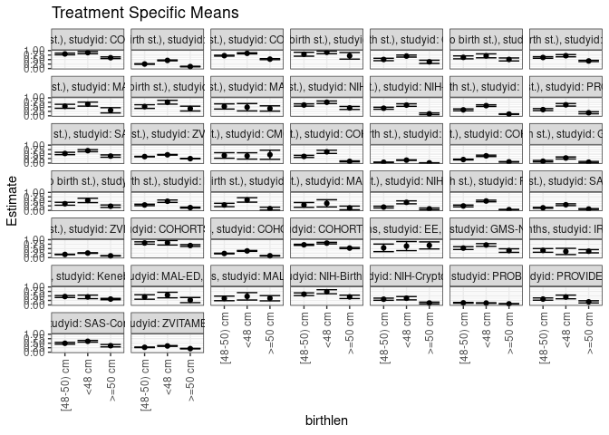

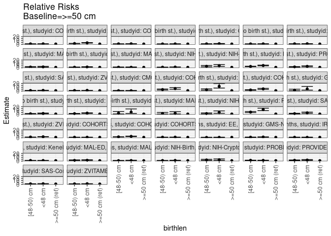

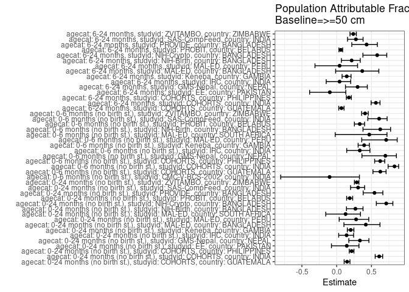

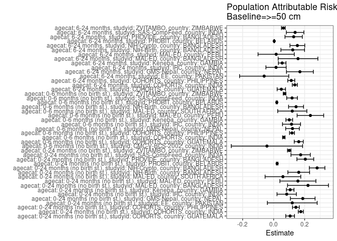

## Results Table

### Parameter: TSM

| agecat | studyid | country | intervention_level | baseline_level | estimate | ci_lower | ci_upper |
| --- | --- | --- | --- | --- | --- | --- | --- |
| 0-24 months (no birth st.) | COHORTS | GUATEMALA | >=50 cm | NA | 0.6018307 | 0.5559056 | 0.6477557 |
| 0-24 months (no birth st.) | COHORTS | GUATEMALA | <48 cm | NA | 0.8849558 | 0.8260886 | 0.9438229 |
| 0-24 months (no birth st.) | COHORTS | GUATEMALA | [48-50) cm | NA | 0.8134921 | 0.7653700 | 0.8616141 |
| 0-24 months (no birth st.) | COHORTS | INDIA | >=50 cm | NA | 0.1115007 | 0.0951629 | 0.1278385 |
| 0-24 months (no birth st.) | COHORTS | INDIA | <48 cm | NA | 0.4540868 | 0.4321656 | 0.4760080 |
| 0-24 months (no birth st.) | COHORTS | INDIA | [48-50) cm | NA | 0.2532787 | 0.2360215 | 0.2705358 |
| 0-24 months (no birth st.) | COHORTS | PHILIPPINES | >=50 cm | NA | 0.5234721 | 0.4943336 | 0.5526106 |
| 0-24 months (no birth st.) | COHORTS | PHILIPPINES | <48 cm | NA | 0.8469565 | 0.8175240 | 0.8763891 |
| 0-24 months (no birth st.) | COHORTS | PHILIPPINES | [48-50) cm | NA | 0.7178602 | 0.6919462 | 0.7437742 |
| 0-24 months (no birth st.) | EE | PAKISTAN | >=50 cm | NA | 0.7083333 | 0.5258340 | 0.8908327 |
| 0-24 months (no birth st.) | EE | PAKISTAN | <48 cm | NA | 0.9032258 | 0.8293696 | 0.9770820 |
| 0-24 months (no birth st.) | EE | PAKISTAN | [48-50) cm | NA | 0.7962963 | 0.6884899 | 0.9041027 |
| 0-24 months (no birth st.) | GMS-Nepal | NEPAL | >=50 cm | NA | 0.3739130 | 0.2854056 | 0.4624205 |
| 0-24 months (no birth st.) | GMS-Nepal | NEPAL | <48 cm | NA | 0.6944444 | 0.6375212 | 0.7513677 |
| 0-24 months (no birth st.) | GMS-Nepal | NEPAL | [48-50) cm | NA | 0.5048077 | 0.4368021 | 0.5728132 |
| 0-24 months (no birth st.) | IRC | INDIA | >=50 cm | NA | 0.5070423 | 0.4246927 | 0.5893918 |
| 0-24 months (no birth st.) | IRC | INDIA | <48 cm | NA | 0.7076923 | 0.5969626 | 0.8184220 |
| 0-24 months (no birth st.) | IRC | INDIA | [48-50) cm | NA | 0.6231884 | 0.5422209 | 0.7041559 |
| 0-24 months (no birth st.) | Keneba | GAMBIA | >=50 cm | NA | 0.4227749 | 0.3877339 | 0.4578159 |
| 0-24 months (no birth st.) | Keneba | GAMBIA | <48 cm | NA | 0.7142857 | 0.6531650 | 0.7754064 |
| 0-24 months (no birth st.) | Keneba | GAMBIA | [48-50) cm | NA | 0.6161616 | 0.5733053 | 0.6590179 |
| 0-24 months (no birth st.) | MAL-ED | BANGLADESH | >=50 cm | NA | 0.3076923 | 0.1624517 | 0.4529329 |
| 0-24 months (no birth st.) | MAL-ED | BANGLADESH | <48 cm | NA | 0.6521739 | 0.5394929 | 0.7648549 |
| 0-24 months (no birth st.) | MAL-ED | BANGLADESH | [48-50) cm | NA | 0.5316456 | 0.4213146 | 0.6419765 |
| 0-24 months (no birth st.) | MAL-ED | PERU | >=50 cm | NA | 0.4038462 | 0.2701604 | 0.5375319 |
| 0-24 months (no birth st.) | MAL-ED | PERU | <48 cm | NA | 0.7580645 | 0.6512066 | 0.8649224 |
| 0-24 months (no birth st.) | MAL-ED | PERU | [48-50) cm | NA | 0.5161290 | 0.4143163 | 0.6179418 |
| 0-24 months (no birth st.) | MAL-ED | SOUTH AFRICA | >=50 cm | NA | 0.4090909 | 0.2631684 | 0.5550134 |
| 0-24 months (no birth st.) | MAL-ED | SOUTH AFRICA | <48 cm | NA | 0.4782609 | 0.2732044 | 0.6833174 |
| 0-24 months (no birth st.) | MAL-ED | SOUTH AFRICA | [48-50) cm | NA | 0.5217391 | 0.3767423 | 0.6667360 |

[output cut: 102 more lines]

### Parameter: E(Y)

| agecat | studyid | country | intervention_level | baseline_level | estimate | ci_lower | ci_upper |
| --- | --- | --- | --- | --- | --- | --- | --- |
| 0-24 months (no birth st.) | COHORTS | GUATEMALA | NA | NA | 0.7082294 | 0.6767491 | 0.7397098 |
| 0-24 months (no birth st.) | COHORTS | INDIA | NA | NA | 0.2867647 | 0.2751726 | 0.2983568 |
| 0-24 months (no birth st.) | COHORTS | PHILIPPINES | NA | NA | 0.6671324 | 0.6498678 | 0.6843969 |
| 0-24 months (no birth st.) | EE | PAKISTAN | NA | NA | 0.8285714 | 0.7659176 | 0.8912252 |
| 0-24 months (no birth st.) | GMS-Nepal | NEPAL | NA | NA | 0.5617391 | 0.5211485 | 0.6023298 |
| 0-24 months (no birth st.) | IRC | INDIA | NA | NA | 0.5913043 | 0.5393557 | 0.6432530 |
| 0-24 months (no birth st.) | Keneba | GAMBIA | NA | NA | 0.5296120 | 0.5040796 | 0.5551444 |
| 0-24 months (no birth st.) | MAL-ED | BANGLADESH | NA | NA | 0.5294118 | 0.4576804 | 0.6011431 |
| 0-24 months (no birth st.) | MAL-ED | PERU | NA | NA | 0.5603865 | 0.4926077 | 0.6281653 |
| 0-24 months (no birth st.) | MAL-ED | SOUTH AFRICA | NA | NA | 0.4690265 | 0.3766048 | 0.5614483 |
| 0-24 months (no birth st.) | NIH-Birth | BANGLADESH | NA | NA | 0.6007828 | 0.5582791 | 0.6432864 |
| 0-24 months (no birth st.) | NIH-Crypto | BANGLADESH | NA | NA | 0.3935681 | 0.3560687 | 0.4310676 |
| 0-24 months (no birth st.) | PROBIT | BELARUS | NA | NA | 0.1205488 | 0.1047261 | 0.1363714 |
| 0-24 months (no birth st.) | PROVIDE | BANGLADESH | NA | NA | 0.3759874 | 0.3382238 | 0.4137509 |
| 0-24 months (no birth st.) | SAS-CompFeed | INDIA | NA | NA | 0.5657407 | 0.5074689 | 0.6240126 |
| 0-24 months (no birth st.) | ZVITAMBO | ZIMBABWE | NA | NA | 0.3494034 | 0.3410405 | 0.3577663 |
| 0-6 months (no birth st.) | CMC-V-BCS-2002 | INDIA | NA | NA | 0.4235294 | 0.3178625 | 0.5291963 |
| 0-6 months (no birth st.) | COHORTS | GUATEMALA | NA | NA | 0.2581047 | 0.2278007 | 0.2884088 |
| 0-6 months (no birth st.) | COHORTS | INDIA | NA | NA | 0.0790014 | 0.0720874 | 0.0859154 |
| 0-6 months (no birth st.) | COHORTS | PHILIPPINES | NA | NA | 0.1893119 | 0.1749594 | 0.2036645 |
| 0-6 months (no birth st.) | GMS-Nepal | NEPAL | NA | NA | 0.1739130 | 0.1429052 | 0.2049209 |
| 0-6 months (no birth st.) | IRC | INDIA | NA | NA | 0.3478261 | 0.2974955 | 0.3981566 |
| 0-6 months (no birth st.) | Keneba | GAMBIA | NA | NA | 0.2552757 | 0.2329715 | 0.2775799 |
| 0-6 months (no birth st.) | MAL-ED | PERU | NA | NA | 0.3333333 | 0.2689597 | 0.3977070 |
| 0-6 months (no birth st.) | MAL-ED | SOUTH AFRICA | NA | NA | 0.2566372 | 0.1757463 | 0.3375280 |
| 0-6 months (no birth st.) | NIH-Birth | BANGLADESH | NA | NA | 0.2309198 | 0.1943452 | 0.2674943 |
| 0-6 months (no birth st.) | PROBIT | BELARUS | NA | NA | 0.0614448 | 0.0507274 | 0.0721623 |
| 0-6 months (no birth st.) | SAS-CompFeed | INDIA | NA | NA | 0.1946247 | 0.1703263 | 0.2189230 |
| 0-6 months (no birth st.) | ZVITAMBO | ZIMBABWE | NA | NA | 0.1729137 | 0.1662801 | 0.1795472 |
| 6-24 months | COHORTS | GUATEMALA | NA | NA | 0.7234469 | 0.6841620 | 0.7627318 |
| 6-24 months | COHORTS | INDIA | NA | NA | 0.2424242 | 0.2305635 | 0.2542850 |
| 6-24 months | COHORTS | PHILIPPINES | NA | NA | 0.6465028 | 0.6261291 | 0.6668766 |
| 6-24 months | EE | PAKISTAN | NA | NA | 0.6206897 | 0.4947260 | 0.7466533 |
| 6-24 months | GMS-Nepal | NEPAL | NA | NA | 0.5631313 | 0.5142177 | 0.6120449 |
| 6-24 months | IRC | INDIA | NA | NA | 0.3733333 | 0.3099915 | 0.4366752 |
| 6-24 months | Keneba | GAMBIA | NA | NA | 0.3816288 | 0.3523153 | 0.4109422 |
| 6-24 months | MAL-ED | BANGLADESH | NA | NA | 0.4275362 | 0.3446947 | 0.5103778 |
| 6-24 months | MAL-ED | PERU | NA | NA | 0.3884298 | 0.3012257 | 0.4756338 |
| 6-24 months | NIH-Birth | BANGLADESH | NA | NA | 0.5727273 | 0.5192737 | 0.6261808 |
| 6-24 months | NIH-Crypto | BANGLADESH | NA | NA | 0.2628458 | 0.2244546 | 0.3012371 |
| 6-24 months | PROBIT | BELARUS | NA | NA | 0.0642659 | 0.0526827 | 0.0758490 |
| 6-24 months | PROVIDE | BANGLADESH | NA | NA | 0.3004386 | 0.2583143 | 0.3425629 |
| 6-24 months | SAS-CompFeed | INDIA | NA | NA | 0.5006242 | 0.4555100 | 0.5457384 |
| 6-24 months | ZVITAMBO | ZIMBABWE | NA | NA | 0.2627189 | 0.2533027 | 0.2721352 |

### Parameter: RR

| agecat | studyid | country | intervention_level | baseline_level | estimate | ci_lower | ci_upper |
| --- | --- | --- | --- | --- | --- | --- | --- |
| 0-24 months (no birth st.) | COHORTS | GUATEMALA | >=50 cm | >=50 cm | 1.0000000 | 1.0000000 | 1.000000 |
| 0-24 months (no birth st.) | COHORTS | GUATEMALA | <48 cm | >=50 cm | 1.4704398 | 1.3288706 | 1.627091 |
| 0-24 months (no birth st.) | COHORTS | GUATEMALA | [48-50) cm | >=50 cm | 1.3516959 | 1.2272891 | 1.488714 |
| 0-24 months (no birth st.) | COHORTS | INDIA | >=50 cm | >=50 cm | 1.0000000 | 1.0000000 | 1.000000 |
| 0-24 months (no birth st.) | COHORTS | INDIA | <48 cm | >=50 cm | 4.0725016 | 3.4902856 | 4.751837 |
| 0-24 months (no birth st.) | COHORTS | INDIA | [48-50) cm | >=50 cm | 2.2715435 | 1.9326006 | 2.669931 |
| 0-24 months (no birth st.) | COHORTS | PHILIPPINES | >=50 cm | >=50 cm | 1.0000000 | 1.0000000 | 1.000000 |
| 0-24 months (no birth st.) | COHORTS | PHILIPPINES | <48 cm | >=50 cm | 1.6179592 | 1.5151958 | 1.727692 |
| 0-24 months (no birth st.) | COHORTS | PHILIPPINES | [48-50) cm | >=50 cm | 1.3713438 | 1.2833149 | 1.465411 |
| 0-24 months (no birth st.) | EE | PAKISTAN | >=50 cm | >=50 cm | 1.0000000 | 1.0000000 | 1.000000 |
| 0-24 months (no birth st.) | EE | PAKISTAN | <48 cm | >=50 cm | 1.2751423 | 0.9731153 | 1.670910 |
| 0-24 months (no birth st.) | EE | PAKISTAN | [48-50) cm | >=50 cm | 1.1241830 | 0.8403017 | 1.503969 |
| 0-24 months (no birth st.) | GMS-Nepal | NEPAL | >=50 cm | >=50 cm | 1.0000000 | 1.0000000 | 1.000000 |
| 0-24 months (no birth st.) | GMS-Nepal | NEPAL | <48 cm | >=50 cm | 1.8572351 | 1.4456976 | 2.385922 |
| 0-24 months (no birth st.) | GMS-Nepal | NEPAL | [48-50) cm | >=50 cm | 1.3500671 | 1.0281878 | 1.772712 |
| 0-24 months (no birth st.) | IRC | INDIA | >=50 cm | >=50 cm | 1.0000000 | 1.0000000 | 1.000000 |
| 0-24 months (no birth st.) | IRC | INDIA | <48 cm | >=50 cm | 1.3957265 | 1.1139313 | 1.748808 |
| 0-24 months (no birth st.) | IRC | INDIA | [48-50) cm | >=50 cm | 1.2290660 | 0.9982707 | 1.513220 |
| 0-24 months (no birth st.) | Keneba | GAMBIA | >=50 cm | >=50 cm | 1.0000000 | 1.0000000 | 1.000000 |
| 0-24 months (no birth st.) | Keneba | GAMBIA | <48 cm | >=50 cm | 1.6895179 | 1.4997738 | 1.903267 |
| 0-24 months (no birth st.) | Keneba | GAMBIA | [48-50) cm | >=50 cm | 1.4574225 | 1.3079603 | 1.623964 |
| 0-24 months (no birth st.) | MAL-ED | BANGLADESH | >=50 cm | >=50 cm | 1.0000000 | 1.0000000 | 1.000000 |
| 0-24 months (no birth st.) | MAL-ED | BANGLADESH | <48 cm | >=50 cm | 2.1195652 | 1.2821673 | 3.503877 |
| 0-24 months (no birth st.) | MAL-ED | BANGLADESH | [48-50) cm | >=50 cm | 1.7278481 | 1.0317327 | 2.893636 |
| 0-24 months (no birth st.) | MAL-ED | PERU | >=50 cm | >=50 cm | 1.0000000 | 1.0000000 | 1.000000 |
| 0-24 months (no birth st.) | MAL-ED | PERU | <48 cm | >=50 cm | 1.8771121 | 1.3098861 | 2.689967 |
| 0-24 months (no birth st.) | MAL-ED | PERU | [48-50) cm | >=50 cm | 1.2780338 | 0.8693351 | 1.878873 |
| 0-24 months (no birth st.) | MAL-ED | SOUTH AFRICA | >=50 cm | >=50 cm | 1.0000000 | 1.0000000 | 1.000000 |
| 0-24 months (no birth st.) | MAL-ED | SOUTH AFRICA | <48 cm | >=50 cm | 1.1690821 | 0.6693066 | 2.042043 |
| 0-24 months (no birth st.) | MAL-ED | SOUTH AFRICA | [48-50) cm | >=50 cm | 1.2753623 | 0.8114343 | 2.004536 |

[output cut: 102 more lines]

### Parameter: PAR

| agecat | studyid | country | intervention_level | baseline_level | estimate | ci_lower | ci_upper |
| --- | --- | --- | --- | --- | --- | --- | --- |
| 0-24 months (no birth st.) | COHORTS | GUATEMALA | >=50 cm | NA | 0.1063988 | 0.0780851 | 0.1347125 |
| 0-24 months (no birth st.) | COHORTS | INDIA | >=50 cm | NA | 0.1752640 | 0.1587982 | 0.1917298 |
| 0-24 months (no birth st.) | COHORTS | PHILIPPINES | >=50 cm | NA | 0.1436603 | 0.1218089 | 0.1655117 |
| 0-24 months (no birth st.) | EE | PAKISTAN | >=50 cm | NA | 0.1202381 | -0.0404240 | 0.2809002 |
| 0-24 months (no birth st.) | GMS-Nepal | NEPAL | >=50 cm | NA | 0.1878261 | 0.1081534 | 0.2674988 |
| 0-24 months (no birth st.) | IRC | INDIA | >=50 cm | NA | 0.0842621 | 0.0218305 | 0.1466937 |
| 0-24 months (no birth st.) | Keneba | GAMBIA | >=50 cm | NA | 0.1068371 | 0.0822894 | 0.1313848 |
| 0-24 months (no birth st.) | MAL-ED | BANGLADESH | >=50 cm | NA | 0.2217195 | 0.0896539 | 0.3537850 |
| 0-24 months (no birth st.) | MAL-ED | PERU | >=50 cm | NA | 0.1565403 | 0.0404079 | 0.2726727 |
| 0-24 months (no birth st.) | MAL-ED | SOUTH AFRICA | >=50 cm | NA | 0.0599356 | -0.0551847 | 0.1750560 |
| 0-24 months (no birth st.) | NIH-Birth | BANGLADESH | >=50 cm | NA | 0.1619339 | 0.0918207 | 0.2320470 |
| 0-24 months (no birth st.) | NIH-Crypto | BANGLADESH | >=50 cm | NA | 0.2804729 | 0.2302601 | 0.3306857 |
| 0-24 months (no birth st.) | PROBIT | BELARUS | >=50 cm | NA | 0.0226558 | 0.0181783 | 0.0271333 |
| 0-24 months (no birth st.) | PROVIDE | BANGLADESH | >=50 cm | NA | 0.2043897 | 0.1502204 | 0.2585590 |
| 0-24 months (no birth st.) | SAS-CompFeed | INDIA | >=50 cm | NA | 0.1742313 | 0.1117890 | 0.2366736 |
| 0-24 months (no birth st.) | ZVITAMBO | ZIMBABWE | >=50 cm | NA | 0.1007364 | 0.0893813 | 0.1120914 |
| 0-6 months (no birth st.) | CMC-V-BCS-2002 | INDIA | >=50 cm | NA | -0.0431373 | -0.2731369 | 0.1868624 |
| 0-6 months (no birth st.) | COHORTS | GUATEMALA | >=50 cm | NA | 0.1619949 | 0.1328454 | 0.1911444 |
| 0-6 months (no birth st.) | COHORTS | INDIA | >=50 cm | NA | 0.0656774 | 0.0575564 | 0.0737983 |
| 0-6 months (no birth st.) | COHORTS | PHILIPPINES | >=50 cm | NA | 0.1184527 | 0.1025357 | 0.1343697 |
| 0-6 months (no birth st.) | GMS-Nepal | NEPAL | >=50 cm | NA | 0.1217391 | 0.0775312 | 0.1659471 |
| 0-6 months (no birth st.) | IRC | INDIA | >=50 cm | NA | 0.1154317 | 0.0572174 | 0.1736460 |
| 0-6 months (no birth st.) | Keneba | GAMBIA | >=50 cm | NA | 0.1008254 | 0.0791209 | 0.1225300 |
| 0-6 months (no birth st.) | MAL-ED | PERU | >=50 cm | NA | 0.2371795 | 0.1514234 | 0.3229356 |
| 0-6 months (no birth st.) | MAL-ED | SOUTH AFRICA | >=50 cm | NA | 0.1202735 | 0.0262608 | 0.2142862 |
| 0-6 months (no birth st.) | NIH-Birth | BANGLADESH | >=50 cm | NA | 0.1445888 | 0.0962813 | 0.1928963 |
| 0-6 months (no birth st.) | PROBIT | BELARUS | >=50 cm | NA | 0.0204108 | 0.0165099 | 0.0243118 |
| 0-6 months (no birth st.) | SAS-CompFeed | INDIA | >=50 cm | NA | 0.1187953 | 0.0842199 | 0.1533706 |
| 0-6 months (no birth st.) | ZVITAMBO | ZIMBABWE | >=50 cm | NA | 0.0706354 | 0.0620918 | 0.0791791 |
| 6-24 months | COHORTS | GUATEMALA | >=50 cm | NA | 0.0496664 | 0.0226156 | 0.0767172 |
| 6-24 months | COHORTS | INDIA | >=50 cm | NA | 0.1366841 | 0.1202456 | 0.1531226 |
| 6-24 months | COHORTS | PHILIPPINES | >=50 cm | NA | 0.1136561 | 0.0911076 | 0.1362046 |
| 6-24 months | EE | PAKISTAN | >=50 cm | NA | -0.0611285 | -0.2197818 | 0.0975248 |
| 6-24 months | GMS-Nepal | NEPAL | >=50 cm | NA | 0.1695143 | 0.0827450 | 0.2562835 |
| 6-24 months | IRC | INDIA | >=50 cm | NA | 0.0155352 | -0.0497737 | 0.0808441 |
| 6-24 months | Keneba | GAMBIA | >=50 cm | NA | 0.0551957 | 0.0306130 | 0.0797784 |
| 6-24 months | MAL-ED | BANGLADESH | >=50 cm | NA | 0.1572660 | 0.0290928 | 0.2854392 |
| 6-24 months | MAL-ED | PERU | >=50 cm | NA | 0.0163367 | -0.1006777 | 0.1333511 |
| 6-24 months | NIH-Birth | BANGLADESH | >=50 cm | NA | 0.1231860 | 0.0468570 | 0.1995150 |
| 6-24 months | NIH-Crypto | BANGLADESH | >=50 cm | NA | 0.1530898 | 0.1053341 | 0.2008454 |
| 6-24 months | PROBIT | BELARUS | >=50 cm | NA | 0.0038343 | 0.0021650 | 0.0055036 |
| 6-24 months | PROVIDE | BANGLADESH | >=50 cm | NA | 0.1292057 | 0.0733460 | 0.1850654 |
| 6-24 months | SAS-CompFeed | INDIA | >=50 cm | NA | 0.1384621 | 0.0818485 | 0.1950756 |
| 6-24 months | ZVITAMBO | ZIMBABWE | >=50 cm | NA | 0.0626527 | 0.0505774 | 0.0747279 |

### Parameter: PAF

| agecat | studyid | country | intervention_level | baseline_level | estimate | ci_lower | ci_upper |
| --- | --- | --- | --- | --- | --- | --- | --- |
| 0-24 months (no birth st.) | COHORTS | GUATEMALA | >=50 cm | NA | 0.1502321 | 0.1075080 | 0.1909109 |
| 0-24 months (no birth st.) | COHORTS | INDIA | >=50 cm | NA | 0.6111770 | 0.5536589 | 0.6612830 |
| 0-24 months (no birth st.) | COHORTS | PHILIPPINES | >=50 cm | NA | 0.2153400 | 0.1808475 | 0.2483801 |
| 0-24 months (no birth st.) | EE | PAKISTAN | >=50 cm | NA | 0.1451149 | -0.0753561 | 0.3203847 |
| 0-24 months (no birth st.) | GMS-Nepal | NEPAL | >=50 cm | NA | 0.3343653 | 0.1744979 | 0.4632727 |
| 0-24 months (no birth st.) | IRC | INDIA | >=50 cm | NA | 0.1425021 | 0.0289060 | 0.2428100 |
| 0-24 months (no birth st.) | Keneba | GAMBIA | >=50 cm | NA | 0.2017271 | 0.1531494 | 0.2475183 |
| 0-24 months (no birth st.) | MAL-ED | BANGLADESH | >=50 cm | NA | 0.4188034 | 0.1042106 | 0.6229142 |
| 0-24 months (no birth st.) | MAL-ED | PERU | >=50 cm | NA | 0.2793435 | 0.0361739 | 0.4611623 |
| 0-24 months (no birth st.) | MAL-ED | SOUTH AFRICA | >=50 cm | NA | 0.1277873 | -0.1565984 | 0.3422480 |
| 0-24 months (no birth st.) | NIH-Birth | BANGLADESH | >=50 cm | NA | 0.2695381 | 0.1408193 | 0.3789728 |
| 0-24 months (no birth st.) | NIH-Crypto | BANGLADESH | >=50 cm | NA | 0.7126413 | 0.5701799 | 0.8078847 |
| 0-24 months (no birth st.) | PROBIT | BELARUS | >=50 cm | NA | 0.1879390 | 0.1434414 | 0.2301250 |
| 0-24 months (no birth st.) | PROVIDE | BANGLADESH | >=50 cm | NA | 0.5436080 | 0.3806585 | 0.6636853 |
| 0-24 months (no birth st.) | SAS-CompFeed | INDIA | >=50 cm | NA | 0.3079702 | 0.1994068 | 0.4018121 |
| 0-24 months (no birth st.) | ZVITAMBO | ZIMBABWE | >=50 cm | NA | 0.2883097 | 0.2552390 | 0.3199119 |
| 0-6 months (no birth st.) | CMC-V-BCS-2002 | INDIA | >=50 cm | NA | -0.1018519 | -0.8043179 | 0.3271266 |
| 0-6 months (no birth st.) | COHORTS | GUATEMALA | >=50 cm | NA | 0.6276324 | 0.5214209 | 0.7102723 |
| 0-6 months (no birth st.) | COHORTS | INDIA | >=50 cm | NA | 0.8313449 | 0.7389717 | 0.8910289 |
| 0-6 months (no birth st.) | COHORTS | PHILIPPINES | >=50 cm | NA | 0.6257015 | 0.5460729 | 0.6913615 |
| 0-6 months (no birth st.) | GMS-Nepal | NEPAL | >=50 cm | NA | 0.7000000 | 0.3631065 | 0.8586891 |
| 0-6 months (no birth st.) | IRC | INDIA | >=50 cm | NA | 0.3318662 | 0.1442262 | 0.4783636 |
| 0-6 months (no birth st.) | Keneba | GAMBIA | >=50 cm | NA | 0.3949668 | 0.3084983 | 0.4706229 |
| 0-6 months (no birth st.) | MAL-ED | PERU | >=50 cm | NA | 0.7115385 | 0.3604435 | 0.8698941 |
| 0-6 months (no birth st.) | MAL-ED | SOUTH AFRICA | >=50 cm | NA | 0.4686520 | -0.0208523 | 0.7234363 |
| 0-6 months (no birth st.) | NIH-Birth | BANGLADESH | >=50 cm | NA | 0.6261432 | 0.3783725 | 0.7751564 |
| 0-6 months (no birth st.) | PROBIT | BELARUS | >=50 cm | NA | 0.3321811 | 0.2547931 | 0.4015325 |
| 0-6 months (no birth st.) | SAS-CompFeed | INDIA | >=50 cm | NA | 0.6103814 | 0.4478537 | 0.7250681 |
| 0-6 months (no birth st.) | ZVITAMBO | ZIMBABWE | >=50 cm | NA | 0.4085011 | 0.3590391 | 0.4541463 |
| 6-24 months | COHORTS | GUATEMALA | >=50 cm | NA | 0.0686525 | 0.0297578 | 0.1059879 |
| 6-24 months | COHORTS | INDIA | >=50 cm | NA | 0.5638218 | 0.4953098 | 0.6230332 |
| 6-24 months | COHORTS | PHILIPPINES | >=50 cm | NA | 0.1758014 | 0.1392614 | 0.2107902 |
| 6-24 months | EE | PAKISTAN | >=50 cm | NA | -0.0984848 | -0.3888305 | 0.1311618 |
| 6-24 months | GMS-Nepal | NEPAL | >=50 cm | NA | 0.3010209 | 0.1264263 | 0.4407206 |
| 6-24 months | IRC | INDIA | >=50 cm | NA | 0.0416121 | -0.1503296 | 0.2015267 |
| 6-24 months | Keneba | GAMBIA | >=50 cm | NA | 0.1446318 | 0.0776715 | 0.2067309 |
| 6-24 months | MAL-ED | BANGLADESH | >=50 cm | NA | 0.3678424 | -0.0149874 | 0.6062777 |
| 6-24 months | MAL-ED | PERU | >=50 cm | NA | 0.0420584 | -0.3119850 | 0.3005620 |
| 6-24 months | NIH-Birth | BANGLADESH | >=50 cm | NA | 0.2150866 | 0.0678626 | 0.3390578 |
| 6-24 months | NIH-Crypto | BANGLADESH | >=50 cm | NA | 0.5824317 | 0.3769269 | 0.7201560 |
| 6-24 months | PROBIT | BELARUS | >=50 cm | NA | 0.0596631 | 0.0323738 | 0.0861829 |
| 6-24 months | PROVIDE | BANGLADESH | >=50 cm | NA | 0.4300570 | 0.2171985 | 0.5850352 |
| 6-24 months | SAS-CompFeed | INDIA | >=50 cm | NA | 0.2765788 | 0.1562593 | 0.3797405 |
| 6-24 months | ZVITAMBO | ZIMBABWE | >=50 cm | NA | 0.2384780 | 0.1914875 | 0.2827375 |